# Assignment 2

Ankit Mithbavkar

10/10/2025

# Introduction

By the age of 6, I believe that children are capable of understanding the concept “most” regardless of the Discrete or Continuous Blocks. That is why my research question is “How is performance different on the Discrete Block vs. Continuous Block for 6-year-olds?” To answer this question, I need to measure the number of correct proportions selected against the type of question.

# Exploration

For this exploration, I need to measure SelectProportion against Block, where SelectProportion represents whether the selected answer was correct (1 = yes and 0 = no) and Block represents the question type (“Cont” = continuous and “Num” = discrete).

```r
library(tidyverse)
```

```r
library(ggplot2)
# Include only subjects where no interference took place and that are 6 years old
df <- read.csv("Most_tidy.csv") |> filter(Exclude == 0, AgeYears == 6)
df
```

| SubID | Order | Gender | AgeMonths | AgeYears | Exclude | ExcludeReason | Block | TrialNumber | SelectProportion |
| --- | --- | --- | --- | --- | --- | --- | --- | --- | --- |
| PM104 | NumFirst | F | 81 | 6 | 0 | NA | Cont | T1 | 0 |
| PM104 | NumFirst | F | 81 | 6 | 0 | NA | Cont | T2 | 0 |
| PM104 | NumFirst | F | 81 | 6 | 0 | NA | Cont | T3 | 0 |
| PM104 | NumFirst | F | 81 | 6 | 0 | NA | Cont | T4 | 0 |
| PM104 | NumFirst | F | 81 | 6 | 0 | NA | Cont | T5 | 0 |
| PM104 | NumFirst | F | 81 | 6 | 0 | NA | Cont | T6 | 0 |
| PM104 | NumFirst | F | 81 | 6 | 0 | NA | Cont | T7 | 0 |
| PM104 | NumFirst | F | 81 | 6 | 0 | NA | Cont | T8 | 0 |
| PM104 | NumFirst | F | 81 | 6 | 0 | NA | Num | T1 | 0 |
| PM104 | NumFirst | F | 81 | 6 | 0 | NA | Num | T2 | 0 |

[output cut: 630 more lines]

Let’s first explore how often 6-year-old children correctly identify the proportion for the Continuous Block.

```r
df$SelectProportion <- as.factor(df$SelectProportion) # Change SelectProportion from an integer type to a factor type (so we can consider it a category)

cont_block_success <- df |>
  filter(Block == "Cont") |> # Take only Continuous block (labeled as "Cont")
  group_by(SelectProportion) |> # Separate the data into Correct (1) and Incorrect (0)
  summarize(Occurrences = n())
cont_block_success
```

| SelectProportion | Occurrences |
| --- | --- |
| 0 | 120 |
| 1 | 200 |

Let’s visualize this as a side-by-side bar chart!

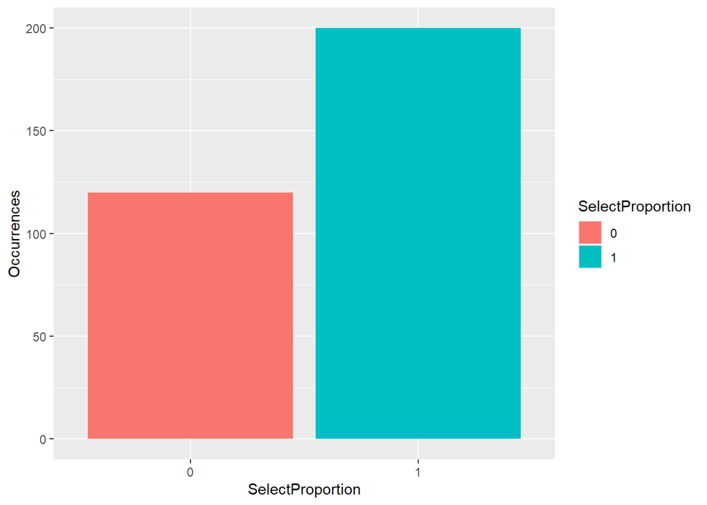

```r
cont_block_success |>
  ggplot(aes(x=SelectProportion, y=Occurrences, fill=SelectProportion)) +
  geom_bar(stat="identity")
```

Let’s now explore how often 6-year-old children correctly identify the correct proportion for the Discrete Block.

```r
disc_block_success <- df |>
  filter(Block == "Num") |> # Take only Discrete block (labeled as "Num")
  group_by(SelectProportion) |> # Separate the data into Correct (1) and Incorrect (0)
  summarize(Occurrences = n())
disc_block_success
```

| SelectProportion | Occurrences |
| --- | --- |
| 0 | 211 |
| 1 | 109 |

Let’s visualize this as a side-by-side bar chart!

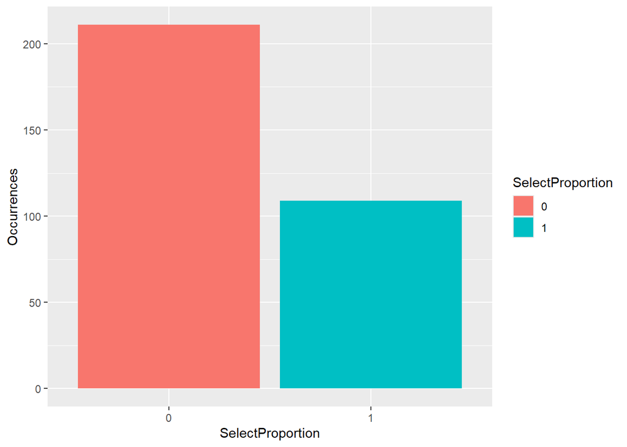

```r
disc_block_success |>
  ggplot(aes(x=SelectProportion, y=Occurrences, fill=SelectProportion)) +
  geom_bar(stat="identity")
```

# Communication

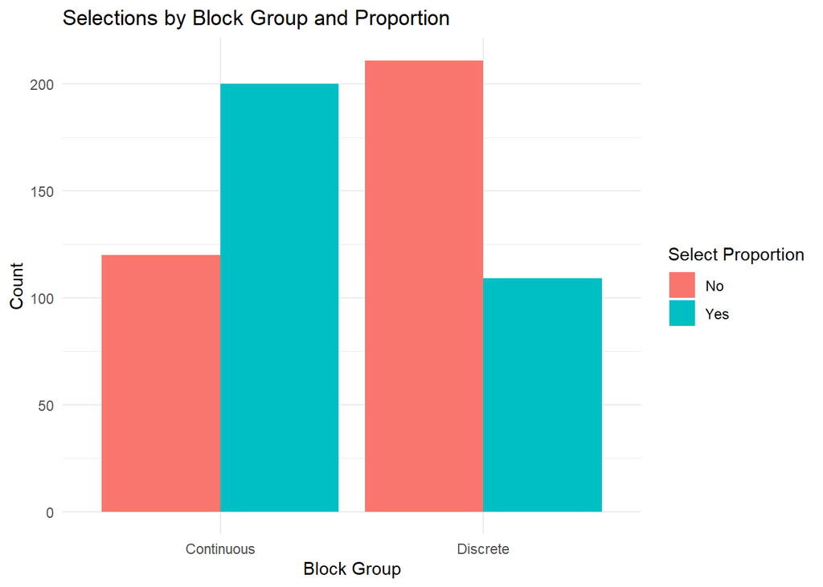

Based on this plot, it’s evident that for 6-year-old children, the Continuous block resulted in more correct selection (better performance) compared to that of the Discrete block. My initial hypothesis was incorrect in that the question type would have no effect in the selections made by this demographic.